# STAT 120 HW 7

Victor Huang

5/17/2021

Section 7.6: Some parts ask you to create quantile-normal plots split by levels of a factor. The code to do this is right above the exercises (also see the example on pages 76-77).

2

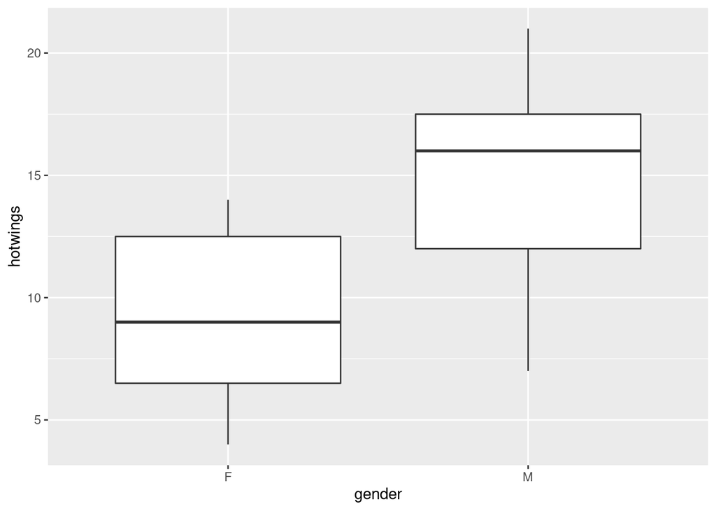

```
## # A tibble: 2 x 3
##   gender `mean(hotwings)` `sd(hotwings)`
##   <chr>             <dbl>          <dbl>
## 1 F                  9.33           3.56
## 2 M                 14.5            4.50
```

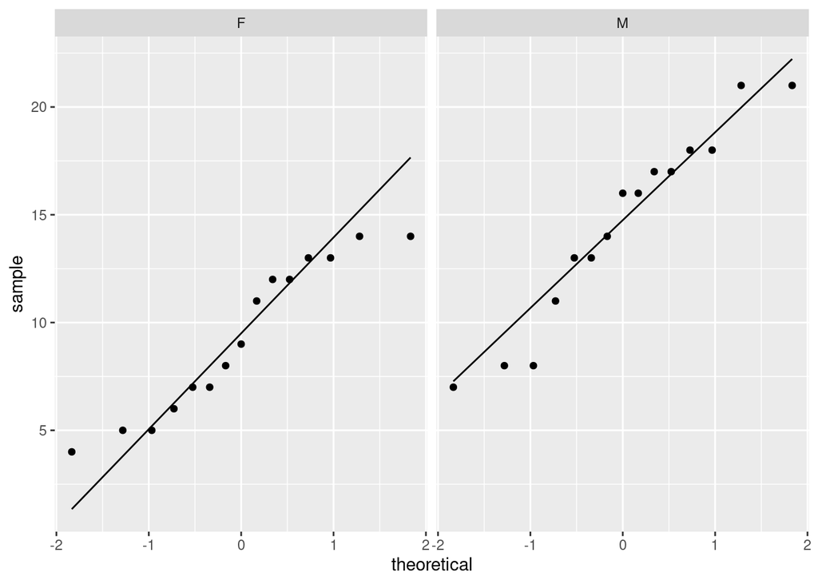

From the graph, one can see that there are some clear outliers to the rough line prescribed by the graph. As such, a normal distribution may not be appropriate and normality may not be met.

```
##
##  Welch Two Sample t-test
##
## data:  hotwings by gender
## t = -3.5094, df = 26.584, p-value = 0.001619
## alternative hypothesis: true difference in means is not equal to 0
## 95 percent confidence interval:
##  -8.242507 -2.157493
## sample estimates:
## mean in group F mean in group M
##        9.333333       14.533333
```

We can conclude that there is a difference in the average number of hotwings consumed between males and females. This is assuming that the data does not match a normal distribution.

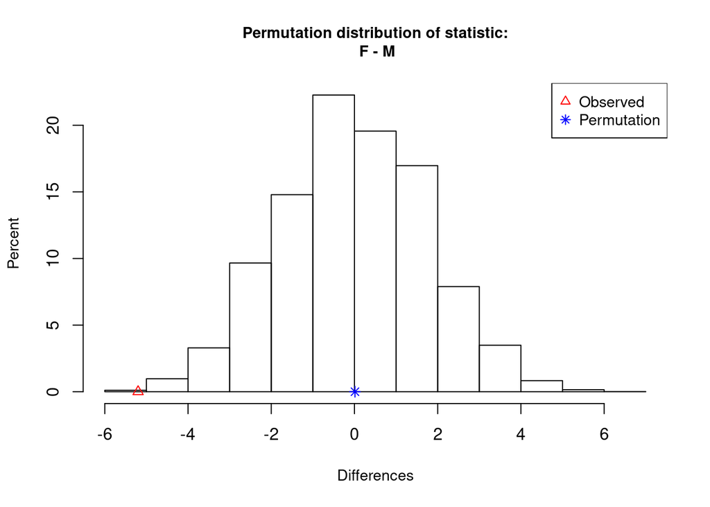

```
##
##  ** Permutation test **
##
##  Permutation test with alternative: two.sided
##  Observed statistic
##   F :  9.33333    M :  14.53333
##  Observed difference: -5.2
##
##  Mean of permutation distribution: 0.01173
##  Standard error of permutation distribution: 1.77144
##  P-value:  0.0016
##
##  *-------------*
```

As one can see, we reach the same conclusion

3

```
##
##  One Sample t-test
##
## data:  facesymmetry$l.pupil
## t = 69.095, df = 30, p-value < 2.2e-16
## alternative hypothesis: true mean is greater than 0
## 95 percent confidence interval:
##  31.62929      Inf
## sample estimates:
## mean of x
##  32.42581
```

From the data displayed above, we fid a 95 confidence interval between 31.62929 to Inf.

Since we get the right and left eye measurements from the same person, this would be a matched-pair setting.

```
##
##  One Sample t-test
##
## data:  eyesdiff
## t = 0.19309, df = 30, p-value = 0.4241
## alternative hypothesis: true mean is greater than 0
## 95 percent confidence interval:
##  -0.5277127        Inf
## sample estimates:
##  mean of x
## 0.06774194
```

From the data showed above, we get a 95% confidence interval from -0.5277 to Inf.

This is an independent sample setting

```
##
##  Welch Two Sample t-test
##
## data:  eyesdiff by eye
## t = -0.55731, df = 22.911, p-value = 0.7086
## alternative hypothesis: true difference in means is greater than 0
## 95 percent confidence interval:
##  -1.684289       Inf
## sample estimates:
## mean in group 1 mean in group 2
##      -0.1055556       0.3076923
```

```
##
##  Welch Two Sample t-test
##
## data:  eyesdiff by hand
## t = -0.7774, df = 7.6238, p-value = 0.7698
## alternative hypothesis: true difference in means is greater than 0
## 95 percent confidence interval:
##  -1.691085       Inf
## sample estimates:
## mean in group 1 mean in group 2
##     0.003703704     0.500000000
```

4

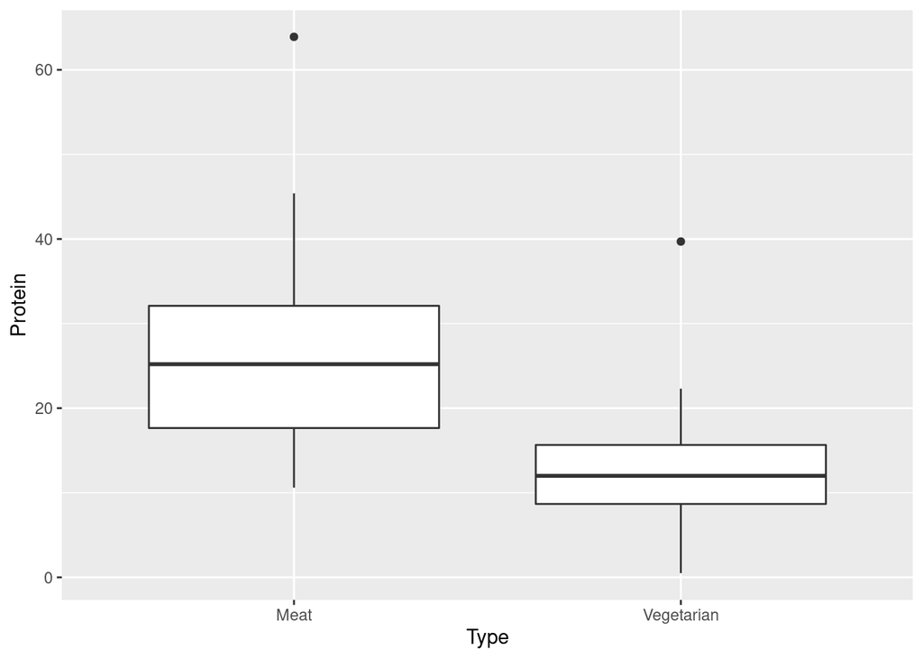

```
## # A tibble: 2 x 3
##   Type       `mean(Protein)` `sd(Protein)`
##   <chr>                <dbl>         <dbl>
## 1 Meat                  27.0         12.0
## 2 Vegetarian            13.3          8.59
```

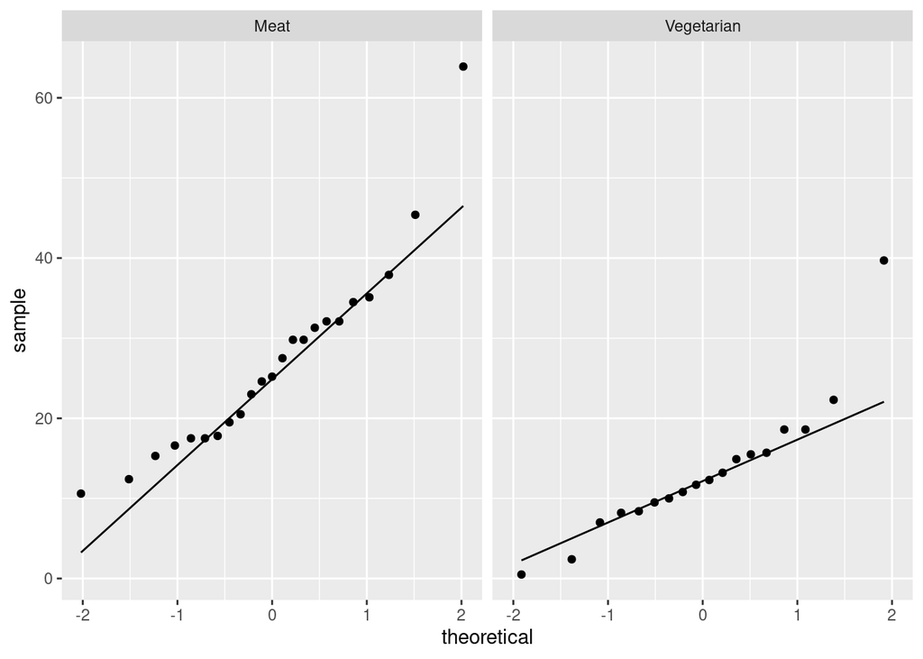

From the graph, one can see that there are some clear outliers to the rough line prescribed by the graph. As such, a normal distribution may not be appropriate and normality may not be met.

```
##
##  Welch Two Sample t-test
##
## data:  Protein by Type
## t = 4.2531, df = 38.769, p-value = 0.0001286
## alternative hypothesis: true difference in means is not equal to 0
## 95 percent confidence interval:
##   7.161098 20.154361
## sample estimates:
##       mean in group Meat mean in group Vegetarian
##                 26.95217                 13.29444
```

As we can clearly see from the data, the mean for meat protein is 26.95217 whereas vegetarian protein is only 13.2944. As such, we conclude that the means are not the same

```
##
##  Welch Two Sample t-test
##
## data:  Protein by Type
## t = 5.7115, df = 35.712, p-value = 1.734e-06
## alternative hypothesis: true difference in means is not equal to 0
## 95 percent confidence interval:
##   8.725291 18.337811
## sample estimates:
##       mean in group Meat mean in group Vegetarian
##                 25.27273                 11.74118
```

Even after getting rid of the outliers, we still come to the same conclusion as before.

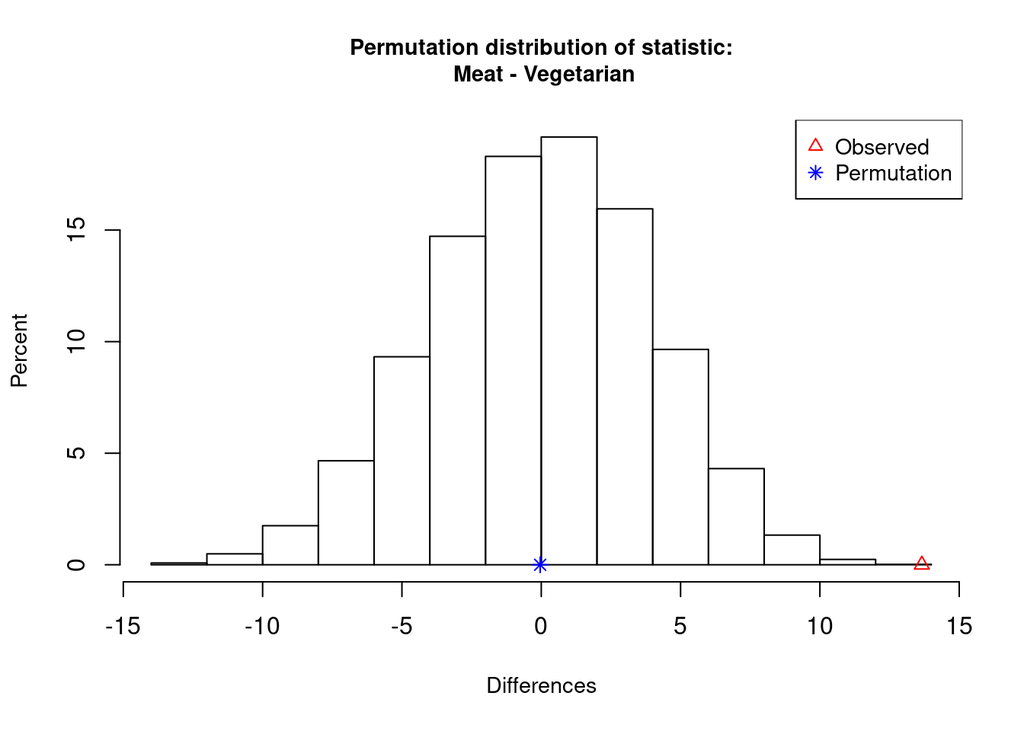

```
##
##  ** Permutation test **
##
##  Permutation test with alternative: two.sided
##  Observed statistic
##   Meat :  26.95217    Vegetarian :  13.29444
##  Observed difference: 13.65773
##
##  Mean of permutation distribution: -0.03907
##  Standard error of permutation distribution: 3.93863
##  P-value:  2e-04
##
##  *-------------*
```

Looking at the data we see that we can reach the same conclusion as above.

Section 7.1

7.4

$p_{1}$ = 280

$p_{2}$ = 40

$p_{3}$ = 40

$p_{4}$ = 40

7.11

$(210 + 732 + 396 + 125 + 213 + 324)(0.35) = 700$

$\frac{(732 - 700)^2}{700} = 1.46$

$df = 6 - 1 = 5$

7.14

$\chi^2 = \frac{(Actual - Expected)^2}{Expected} = \frac{(66 - 39.67)^2}{39.67} + \frac{(39 - 39.67)^2}{39.67} + \frac{(14 - 39.67)^2}{39.67} = 34.0980$

Looking at our $\chi^2$ value, we can say that there are proportions that aren’t the $\frac{1}{3}$ outcome we expect, we find that the win count for rock and scissors don’t match the one-third win rate

7.16

$df = 5 - 1 = 4$

Confidence Level: 5%

$\chi^2 = \frac{(Actual - Expected)^2}{Expected} = \frac{(391 - 410)^2}{410} + \frac{(257 - 280)^2}{280} + \frac{(156 - 130)^2}{130} + \frac{(89 - 70)^2}{70} + \frac{(107 - 110)^2}{110} = 13.2087$

p-value = 0.010

Summarizing our data, we can conclude that the data given by the article is not accurate.

7.26

p-value = 0.3350